# Assessing the Suitability of Semi-Supervised Learning Datasets with Item Response Theory

Fredriksson, T., Mattos, D.I., Bosch, J. and Olsson, H. H.

2021-03-26

# Loaded libraries

```r
library(tidyverse)
library(cmdstanr)
library(posterior)
library(bayesplot)
library(kableExtra)
library(latex2exp)
seed <- 20200331
set.seed(seed)
```

# Importing the data

```r
d <- read_csv('data/full_data.csv') %>%
  rename("Accuracy"=value) %>%
  select(-X1) %>%
  mutate(Accuracy = Accuracy/100) #between 0 and 1
```

Obtaining a numerical index for the dataset and the model

```r
#convert to factor
d$Model <- as.factor(d$Model)
d$Dataset <- as.factor(d$Dataset)
#convert to integer
d$ModelIndex <- as.numeric(d$Model)
d$DatasetIndex <- as.numeric(d$Dataset)
#vector with the names in order
models <- levels(d$Model)
datasets <- levels(d$Dataset)
```

# IRT Bayesian congeneric model in Stan

We are using below a Bayesian version of the congeneric model described in the Handbook of Item Response Theory Vol.1 chapter 10.

This model is coded in Stan, compiled to C++. The code of the model is shown below.

Loading and compiling the model

```r
stanmodel <- cmdstan_model('models/congeneric.stan')
```

```
## Model executable is up to date!
```

Code of the model

```r
stanmodel$print()
```

```
## // IRT Congeneric model
## // Author:David Issa Mattos
## // Date: 25 March 2021
##
## data {
##   int<lower=0> N; // size of the vector
##   vector[N] y; // response of the item
##   int p[N]; // test taker index(the model)
##   int<lower=0> Np; // number of test takes (number of models)
##   int item[N]; // item index of the test (the dataset)
##   int<lower=0> Nitem; // number of items in the test
## }
##
##
## parameters {
##  real<lower=0> b[Nitem]; // difficulty parameter
##  real<lower=0> a[Nitem]; // discrimination parameter
##  real<lower=0> theta[Np]; // ability of the test taker
##  real<lower=0> sigma;
## }
##
## model {
##   real mu[N];
##
##   //Weakly informative priors
##   b ~ normal(0, 1);
##   a ~ normal(0,1);
##   theta ~ normal(0,3);
##   sigma ~ normal(0,1);//halfnormal
##
##   //Linear gaussian model
##   for(i in 1:N){
##     mu[i] = b[item[i]] + a[item[i]]*theta[p[i]];
##   }
##   y ~ normal(mu, sigma);
##
## }
##
## generated quantities{
##   vector[N] log_lik;
##   vector[N] y_rep;
##   for(i in 1:N){
##     real mu;
##     mu = b[item[i]] + a[item[i]]*theta[p[i]];
##     log_lik[i] = normal_lpdf(y[i] | mu, sigma );
##     y_rep[i] = normal_rng( mu, sigma);
##   }
## }
```

## Standata

Here we create the list of data that will be passed to Stan

```r
standata <- list(
  N = nrow(d),
  y = d$Accuracy,
  p = d$ModelIndex,
  Np = length(models),
  item = d$DatasetIndex,
  Nitem = length(datasets)
)
```

## Running the model

```r
fit <- stanmodel$sample(
  data= standata,
  seed = seed,
  chains = 4,
  parallel_chains = 4,
  max_treedepth = 15
)
fit$save_object(file='models/fit.RDS')
```

To load the fitted model to save time in compiling this document

```r
fit<-readRDS('models/fit.RDS')
```

## Checks

Posterior draws

```r
draws_a <- fit$draws('a')
draws_b <- fit$draws('b')
draws_theta <- fit$draws('theta')
draws_sigma <- fit$draws('sigma')
```

### Traceplots

Traceplots for a

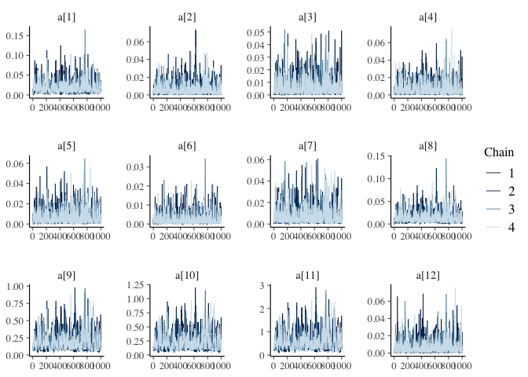

```r
mcmc_trace(draws_a)
```

Traceplots for b

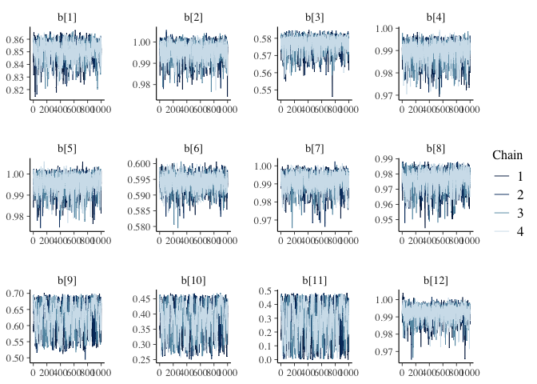

```r
mcmc_trace(draws_b)
```

Traceplots for theta

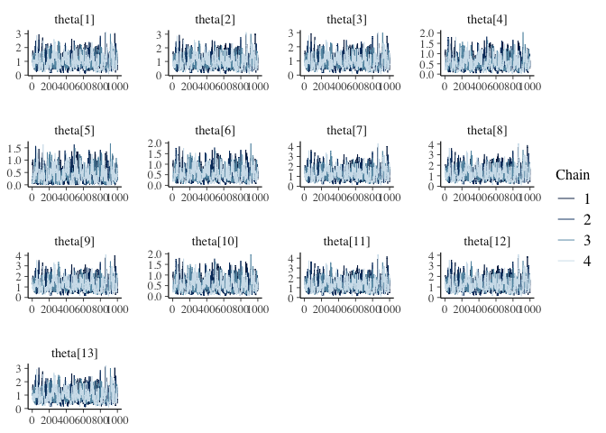

```r
mcmc_trace(draws_theta)
```

Traceplot for sigma

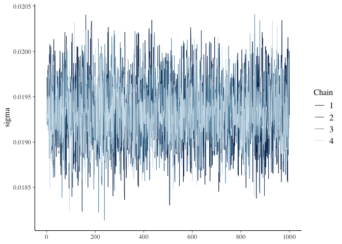

```r
mcmc_trace(draws_sigma)
```

## Posterior predictive

```r
y <- standata$y
yrep <- posterior::as_draws_matrix(fit$draws('y_rep'))
```

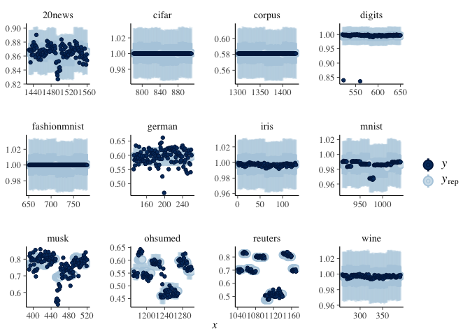

```r
ppc_intervals_grouped(y, yrep, group=d$Dataset)
```

# Results

Let’s first get a summary table of the estimated values of the model with 90% credible interval

```r
fit_summary_datasets <- fit$summary(c('a','b'))
fit_summary_models <- fit$summary(c('theta'))
fit_summary_sigma <- fit$summary(c('sigma'))
```

Creating a table for the datasets

```r
table_datasets <- fit_summary_datasets %>%
  select(Dataset=variable,
         Median=median,
         'CI 5%'=q5,
         'CI 95%'=q95)

table_datasets$Dataset <- rep(datasets,2)

kable(table_datasets,
      caption='Summary values of the discrimination and easiness level parameters for the datasets',
      booktabs=T,
      digits =3,
      format='html') %>%
  kable_styling() %>%
  pack_rows("Discrimination value (a)",1,12) %>%
  pack_rows("Easiness level (b)",13,24)
```

Summary values of the discrimination and easiness level parameters for the datasets

| Dataset | Median | CI 5% | CI 95% |
| --- | --- | --- | --- |
| **Discrimination value (a)** |  |  |  |
| 20news | 0.015 | 0.004 | 0.047 |
| cifar | 0.004 | 0.000 | 0.018 |
| corpus | 0.004 | 0.000 | 0.018 |
| digits | 0.005 | 0.000 | 0.020 |
| fashionmnist | 0.004 | 0.000 | 0.018 |
| german | 0.001 | 0.000 | 0.008 |
| iris | 0.005 | 0.001 | 0.022 |
| mnist | 0.011 | 0.002 | 0.035 |
| musk | 0.157 | 0.066 | 0.413 |
| ohsumed | 0.186 | 0.078 | 0.491 |
| reuters | 0.462 | 0.193 | 1.201 |
| wine | 0.005 | 0.000 | 0.020 |
| **Easiness level (b)** |  |  |  |
| 20news | 0.852 | 0.837 | 0.861 |
| cifar | 0.996 | 0.988 | 1.001 |
| corpus | 0.578 | 0.569 | 0.582 |
| digits | 0.990 | 0.981 | 0.995 |
| fashionmnist | 0.996 | 0.988 | 1.001 |
| german | 0.594 | 0.590 | 0.598 |
| iris | 0.993 | 0.983 | 0.998 |
| mnist | 0.977 | 0.964 | 0.985 |
| musk | 0.637 | 0.546 | 0.688 |
| ohsumed | 0.396 | 0.289 | 0.456 |
| reuters | 0.312 | 0.047 | 0.462 |
| wine | 0.993 | 0.984 | 0.998 |

Creating a table for the models ability

```r
table_models <- fit_summary_models %>%
  select(Model=variable,
         Median=median,
         'CI 5%'=q5,
         'CI 95%'=q95)

table_models$Model <- models

kable(table_models,
      caption='Summary values of the ability level of the SSL models',
      booktabs=T,
      digits =3,
      format='html') %>%
  kable_styling()
```

Summary values of the ability level of the SSL models

| Model | Median | CI 5% | CI 95% |
| --- | --- | --- | --- |
| centeredkernel | 0.896 | 0.353 | 1.848 |
| laplace | 0.880 | 0.344 | 1.809 |
| mean_shifted_laplace | 0.858 | 0.340 | 1.777 |
| poisson | 0.441 | 0.134 | 1.089 |
| poisson2 | 0.324 | 0.031 | 0.924 |
| poissonbalanced | 0.435 | 0.131 | 1.085 |
| poissonmbo | 1.131 | 0.447 | 2.317 |
| poissonmbo_old | 1.092 | 0.430 | 2.239 |
| poissonmbobalanced | 1.094 | 0.430 | 2.234 |
| poissonvolume | 0.427 | 0.122 | 1.069 |
| randomwalk | 1.150 | 0.453 | 2.366 |
| sparselabelpropagation | 1.096 | 0.433 | 2.242 |
| wnll | 0.898 | 0.353 | 1.856 |

We can also get a representative figure of these tables

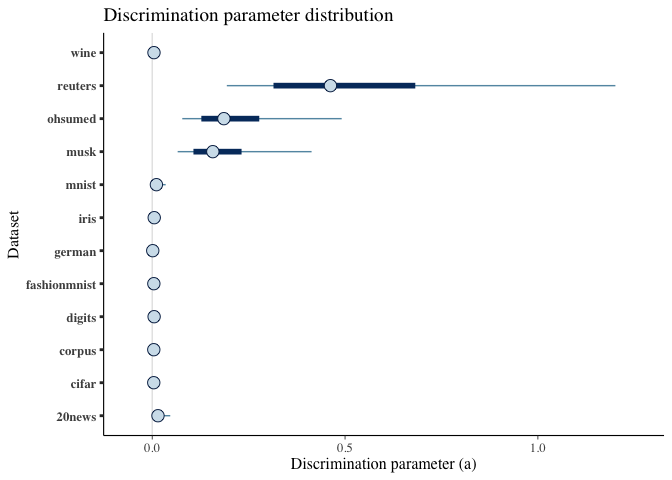

```r
mcmc_intervals(draws_a) +
  scale_y_discrete(labels=datasets)+
  labs(x='Discrimination parameter (a)',
       y='Dataset',
       title='Discrimination parameter distribution')
```

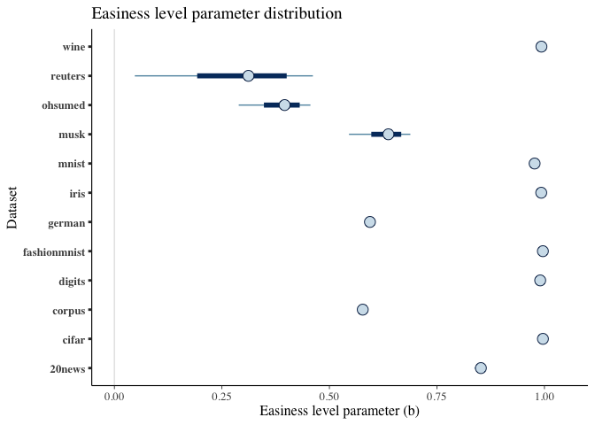

```r
mcmc_intervals(draws_b) +
  scale_y_discrete(labels=datasets)+
  labs(x='Easiness level parameter (b)',
       y='Dataset',
       title='Easiness level parameter distribution')
```

We can observe the actual average values of accuracy for each one of these datasets

```r
d %>% group_by(Dataset) %>%
  summarise('Mean accuracy'=mean(Accuracy)) %>%
  kable(caption = 'Average accuracy for each dataset',
        booktabs=T,
        digits=3,
        format='html') %>%
  kable_styling()
```

Average accuracy for each dataset

| Dataset | Mean accuracy |
| --- | --- |
| 20news | 0.865 |
| cifar | 1.000 |
| corpus | 0.581 |
| digits | 0.994 |
| fashionmnist | 1.000 |
| german | 0.596 |
| iris | 0.997 |
| mnist | 0.986 |
| musk | 0.764 |
| ohsumed | 0.546 |
| reuters | 0.685 |
| wine | 0.997 |

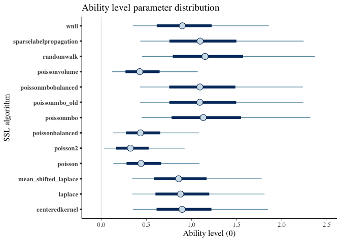

```r
mcmc_intervals(draws_theta) +
  scale_y_discrete(labels=models)+
  labs(x=unname(TeX("Ability level ($\\theta$)")),
       y='SSL algorithm',
       title='Ability level parameter distribution')
```

From this analysis we can see that most of the datasets used in SSL evaluations have low discrimination factor and high easiness levels. Datasets with very high easiness levels and low discrimination might be usesful to observe if the algorithm is correctly implemented but not to be used to compare different algorithms.

From the ability levels of the SSL algorithms, we can observe that some groups of algorithms perform better than others but there is little difference between them.

The following cmdstan version was used for compiling and sampling the model

```r
cmdstanr::cmdstan_version()
```

```
## [1] "2.26.0"
```